# MATH118_HW1

Jackson Evans

9/23/2021

Loading libraries

```r
library("ggplot2")
library(dplyr)
library(tidyverse)
library(openintro)
library('outliers')
library('EnvStats')
library(reshape)
```

1. What is the least expensive Mario Kart game that included at least 1 steering wheel in the ebay auction?

```r
mariokart %>%
  filter(wheels>0) %>%
  summarize(min(total_pr))
```

```
## # A tibble: 1 × 1
##   `min(total_pr)`
##             <dbl>
## 1            33.0
```

By filtering our data to exclude sales without a wheel, we can find that the minimum price of a game sold including at least one steering wheel was $33.01.

2. Calculate the value of the range of shipping prices for each shipping speed/method. Which shipping speed/method had the largest range of shipping prices, and which had the smallest range?

```r
mariokart %>%
  group_by(ship_sp) %>%
  na.omit() %>%
  summarize(max(ship_pr)-min(ship_pr))
```

```
## # A tibble: 8 × 2
##   ship_sp    `max(ship_pr) - min(ship_pr)`
##   <fct>                              <dbl>
## 1 firstClass                           4
## 2 media                                4
## 3 other                                4
## 4 parcel                              25.5
## 5 priority                            10.4
## 6 standard                             4
## 7 ups3Day                              0
## 8 upsGround                           11.4
```

The parcel shipping method had the largest range of shipping prices at 25.51 dollars, while the ups3Day had the least, at 0 dollars. We must note, however, that the ups3Day shipping method was only used once and therefore has no range. Hence we need to recognize the impact of sample size in finding ranges. Just a calculation of range may not tell the full story. The next method(s) with the smallest range of prices are firstClass, media, other and standard with a range of 4 dollars.

3. Calculate the mean and median total prices of new Mario Kart games and used Mario Kart games. Explain your findings using a graph.

```r
mariokart %>%
  group_by(cond)%>%
  summarize(mean=mean(total_pr), median=median(total_pr))
```

```
## # A tibble: 2 × 3
##   cond   mean median
##   <fct> <dbl>  <dbl>
## 1 new    53.8   54.0
## 2 used   47.1   42.8
```

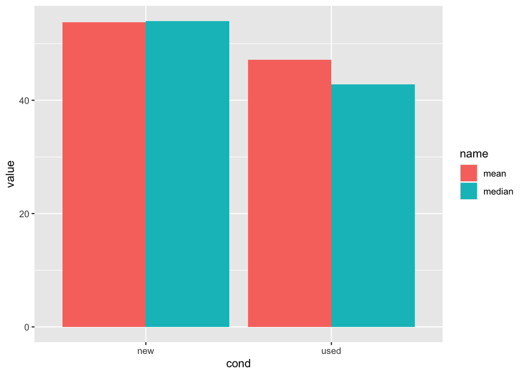

```r
mariokart %>%
  group_by(cond)%>%
  summarize(mean=mean(total_pr), median=median(total_pr)) %>%
  pivot_longer(!cond)%>%
  ggplot(aes(x=cond, y=value, fill=name))+
  geom_bar(position='dodge', stat='identity')
```

The graphs are fairly self explanatory. For new condition sales, the mean and median are comprable, however there seems to be a significant difference in mean and median for used games. This suggests that large value outliers are skewing the mean of the used condition sales.

4. Investigate why you obtained the results in 3).

```r
mariokart%>%
  group_by(cond) %>%
  filter(is.na(total_pr))
```

```
## # A tibble: 0 × 12
## # Groups:   cond [0]
## # … with 12 variables: id <dbl>, duration <int>, n_bids <int>, cond <fct>,
## #   start_pr <dbl>, ship_pr <dbl>, total_pr <dbl>, ship_sp <fct>,
## #   seller_rate <int>, stock_photo <fct>, wheels <int>, title <fct>
```

There are no NA values. This doesn’t explain why used games have a marginal difference in mean and median. Perhaps there is an outlier?

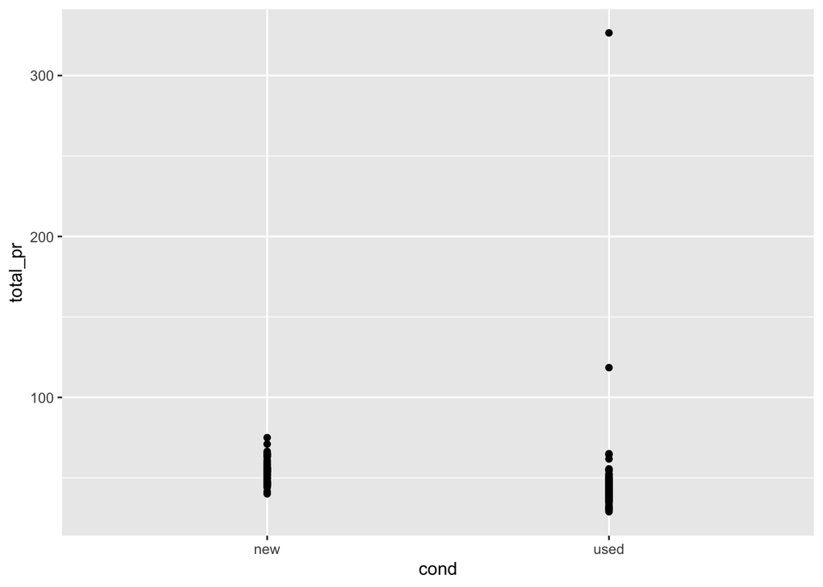

```r
ggplot(data=mariokart) +
  geom_point(mapping=aes(x=cond,y=total_pr))
```

Here we can see that there is an outlier for the used games at over 300 dollars. Investigating this data point illuminates that this sale was a bundle including a Nintendo Wii console and a Guitar Hero 5 game along with Mario Kart. Similarly, the second most expensive sale was a 10 game bundle and also skews the data. Together these data points affect the mean price of used Mario Kart sales.

5. Remove any problem point and/or severe outliers from your data set, if they exist. Justify. As shown above there are two significant outliers.

```r
used<-mariokart%>%
  filter(cond=='used')

outlier_test<-rosnerTest(used$total_pr, k=2)
outlier_test$all.stats
```

```
##   i   Mean.i     SD.i  Value Obs.Num    R.i+1 lambda.i+1 Outlier
## 1 0 47.14810 32.74211 326.51       7 8.532190   3.323491    TRUE
## 2 1 43.78229 11.04119 118.50      37 6.767182   3.319245    TRUE
```

Therefore based on the Rosner Test we can see that the two largest total prices for used mario kart games are outliers. Aside from their outlier values, we also should note that since they were fundamentally selling additional and different materials, that they should be excluded from the rest of the testing of the data set. However, if we keep repeating this test we will perhaps find more outliers with respect to the new data set. Let’s double check this with 3 to make sure these are the only two outliers mathematically - however these are the only two points that don’t belong in the data set principally.

```r
used<-mariokart%>%
  filter(cond=='used')

outlier_test<-rosnerTest(used$total_pr, k=3)
outlier_test$all.stats
```

```
##   i   Mean.i      SD.i  Value Obs.Num    R.i+1 lambda.i+1 Outlier
## 1 0 47.14810 32.742108 326.51       7 8.532190   3.323491    TRUE
## 2 1 43.78229 11.041186 118.50      37 6.767182   3.319245    TRUE
## 3 2 42.87110  7.324591  65.02      50 3.023910   3.314935   FALSE
```

Therefore the next value is not an outlier and since it its product is congruent with the theme of the data set, we will not remove it.

6. Calculate the median total price for each combination of game condition and whether or not the auction contained any number of steering wheels. Report these values.

```r
mariokart%>%
  mutate(any_wheels=wheels>0)%>%
  filter(id!=130335427560 & id!= 110439174663)%>%
  group_by(cond,any_wheels)%>%
  summarize(median(total_pr))
```

```
## # A tibble: 4 × 3
## # Groups:   cond [2]
##   cond  any_wheels `median(total_pr)`
##   <fct> <lgl>                   <dbl>
## 1 new   FALSE                    47.4
## 2 new   TRUE                     54.0
## 3 used  FALSE                    38.0
## 4 used  TRUE                     45.5
```

The median total price for a new game containing any wheels was 53.99 dollars; The median total price for a new game containing no wheels was 47.375 dollars; The median total price for a used game containing wheels was 45.48 dollars; The median total price for a used game containing no wheels was 38.03 dollars.

7. Construct and interpret a single graphic that describes the relationship between the variables: starting price, total price, condition, and whether or not the auction used a stock photo.

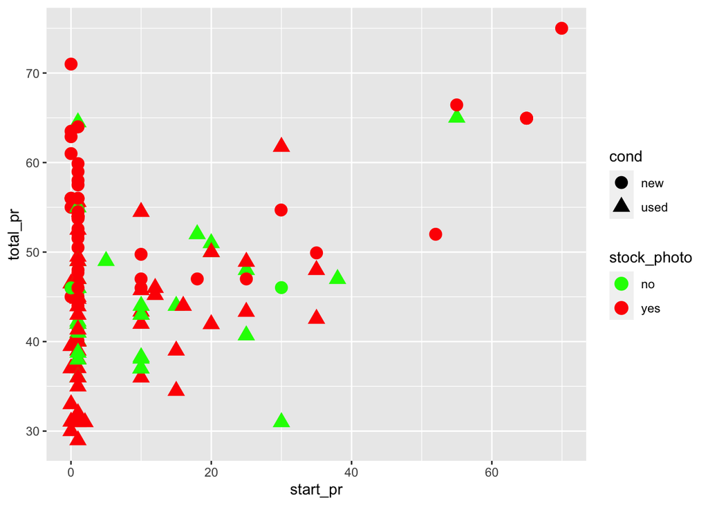

```r
mariokart %>%
  filter(id!=130335427560 & id!= 110439174663) %>%
  ggplot()+
  geom_point(aes(y=total_pr, x=start_pr, color=stock_photo, shape=cond), size = 4)+
  scale_shape_manual(values = c('new'=16, 'used'=17))+
  scale_color_manual(values = c('green','red')) +
  scale_size_area(max_size=4)
```

Based on this graphic, it seems as though the use of a stock photo does not have a tremendous impact on total price, but improves it slightly. It also seems as though materials in new condition have a higher start and total price.

8. If I could control all variables of a copy of Mario Kart Wii, what is the optimal set of variables to maximize the total selling price of the game?

Firstly, let’s look at number of wheels.

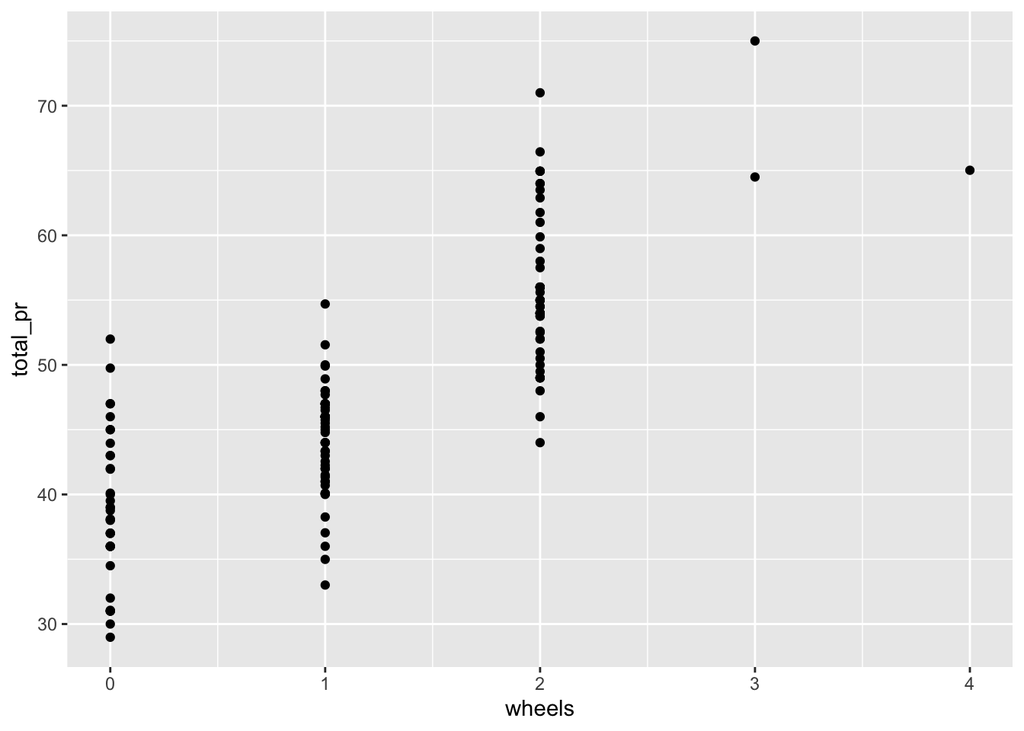

```r
mariokart%>%
  filter(id!=130335427560 & id!= 110439174663) %>%
  ggplot() +
  geom_point(mapping=aes(x=wheels,y=total_pr))
```

Assuming the post will definitely be sold, it seems logical to maximize the number of wheels to infinity to maximize the material value. However, attempting to sell 500 wheels bundled with Mario Kart may not well fit into a supply/demand analysis.

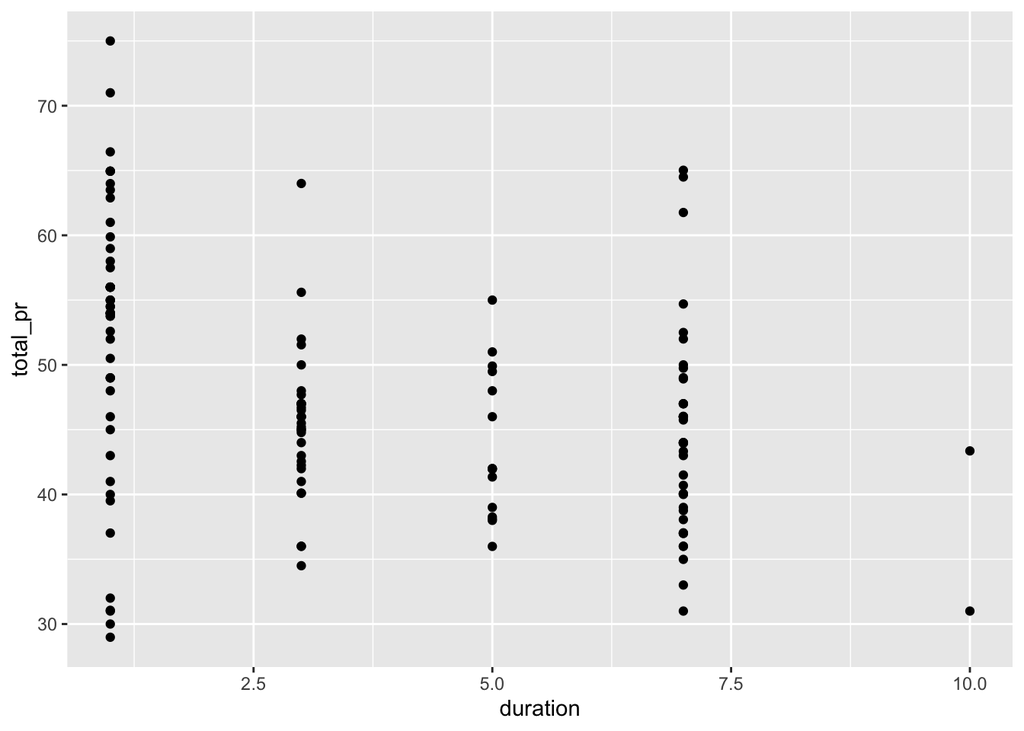

```r
mariokart%>%
  filter(id!=130335427560 & id!= 110439174663) %>%
  ggplot() +
  geom_point(mapping=aes(x=duration,y=total_pr))
```

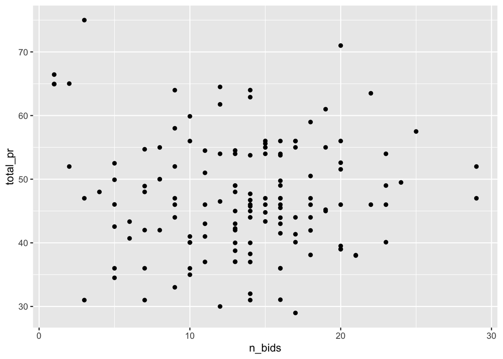

```r
mariokart%>%
  filter(id!=130335427560 & id!= 110439174663) %>%
  ggplot() +
  geom_point(mapping=aes(x=n_bids,y=total_pr))
```

Somewhat counterintuitively, it seems as though the number of bids does not correlate to a higher total sale price. Similarly, I choose not to place a stipulation on the number of bids.

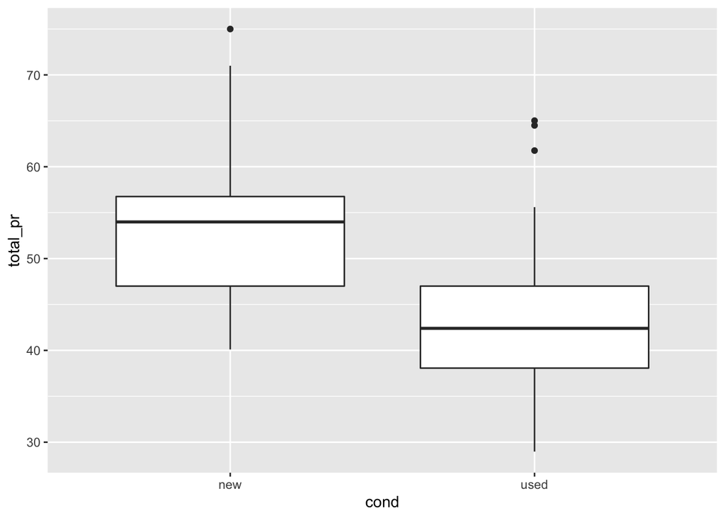

```r
mariokart%>%
  filter(id!=130335427560 & id!= 110439174663) %>%
  ggplot() +
  geom_boxplot(mapping=aes(x=cond,y=total_pr))
```

As shown previously, after accounting for outliers, a new Mario Kart game is preferred to a used one.

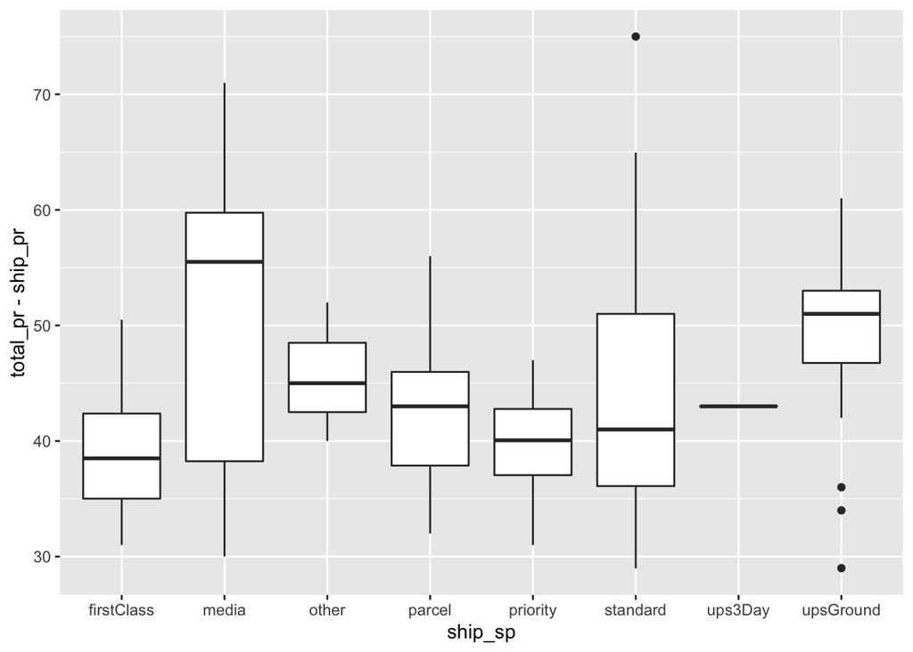

```r
mariokart%>%
  filter(id!=130335427560 & id!= 110439174663) %>%
  ggplot() +
  geom_boxplot(mapping=aes(x=ship_sp,y=total_pr-ship_pr))
```

Either media or upsGround seem to be the best shipping method, however more information needs to be gained here. Do shipping costs provide profit to the transaction for the seller, or do they go to Ebay? In this graph I subtracted the shipping price from the total price to get a more clear idea of its impact. While Media or upsground seems to be preferred, more information is needed on this variable for a full picture.

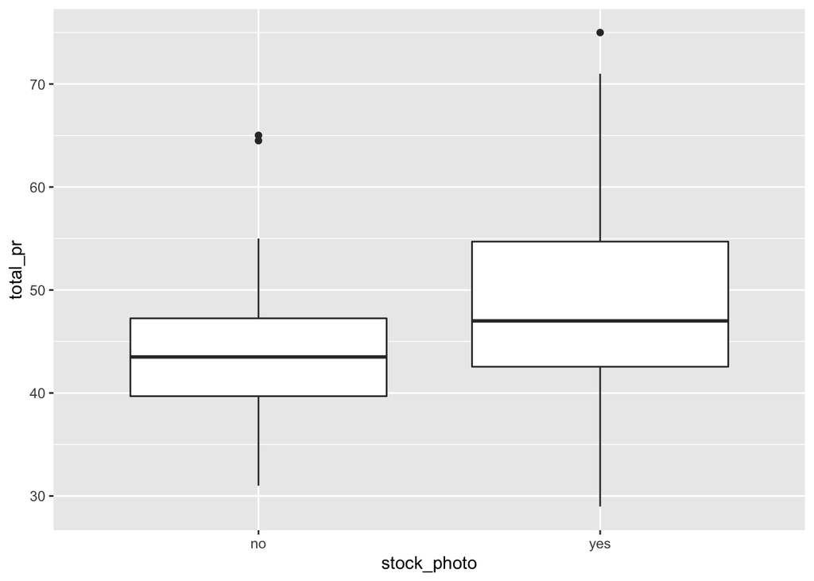

```r
mariokart%>%
  filter(id!=130335427560 & id!= 110439174663) %>%
  ggplot() +
  geom_boxplot(mapping=aes(x=stock_photo,y=total_pr))
```

As per question 7, having a stock photo improves the total price of the sale. I would include a stock photo.

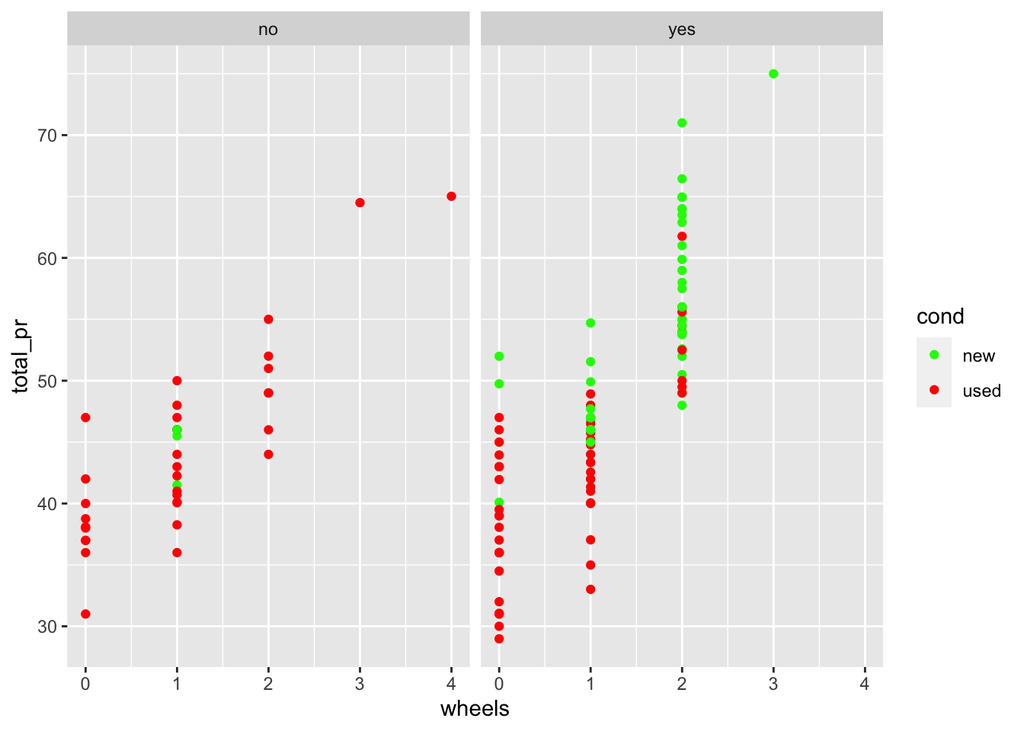

```r
#Try to make a bunch of graphs in one
mariokart%>%
  filter(id!=130335427560 & id!= 110439174663)%>%
  ggplot() +
  geom_point(mapping=aes(x=wheels,y=total_pr, color=cond)) +
  scale_color_manual(values = c('green','red')) +
  facet_grid(~stock_photo)
```

Ultimately, I would sell a new Mario Kart game with a stock photo and as many wheels as possible. The question of shipping method would be dependent on Ebay’s back-end regulations and customer demand.